# R Notebook

## Event study

For event study to see how the effect of the expansion differ between two groups I did it in two different ways.

1. Running the equation 1 on two sample of Foreign and Native
2. Use the interaction term for Foreign-born following the equation 2

problem with using the second method is that the power of the analysis might reduce dramaticly. Maybe I can do the power analysis instead of checking all these

I want to see how these two approach differ here is how

when I use no adjustment

### Event study table no adjustment Check different specifications

```r
# with no adjustment on two samples
Event= feols( UNINS ~ i(ttot, expansion, ref = -1) |
                   ST + YEAR   ,                        ## FEs
               vcov="hetero",
               #  cluster = "ST",
               weights = ~PWGTP,
               data = Data,
               split= ~NATIVITY)
# with no adjustment with interaction

Event1= feols( UNINS ~ ForeginBorn*i(ttot, expansion, ref = -1) |
                ST + YEAR   ,                        ## FEs
              vcov="hetero",
              #  cluster = "ST",
              weights = ~PWGTP,
              data = Data)

etable(Event, Event1)
```

```
                                                Event.1             Event.2              Event1
Sample (NATIVITY)                               US-born        Foregin-born
Dependent Var.:                                   UNINS               UNINS               UNINS

expansion x ttot = -8                  -0.0045 (0.0100)    0.0593* (0.0263)    -0.0036 (0.0098)
expansion x ttot = -7                  -0.0142 (0.0097)    0.0432. (0.0256)    -0.0120 (0.0095)
expansion x ttot = -6                  -0.0117 (0.0095)     0.0089 (0.0243)    -0.0104 (0.0093)
expansion x ttot = -5                 0.0214** (0.0072)     0.0070 (0.0221)   0.0214** (0.0071)
expansion x ttot = -4                  -0.0014 (0.0052)    -0.0124 (0.0162)     0.0018 (0.0051)
expansion x ttot = -3                  -0.0010 (0.0034)    -0.0043 (0.0072)     0.0033 (0.0032)
expansion x ttot = -2                   0.0047 (0.0032)     0.0024 (0.0070)   0.0099** (0.0031)
expansion x ttot = 0                -0.0525*** (0.0031) -0.0346*** (0.0072) -0.0460*** (0.0030)
expansion x ttot = 1                -0.0901*** (0.0032) -0.0690*** (0.0074) -0.0810*** (0.0030)
expansion x ttot = 2                -0.0995*** (0.0033) -0.0763*** (0.0076) -0.0875*** (0.0031)
expansion x ttot = 3                -0.0993*** (0.0033) -0.0898*** (0.0078) -0.0881*** (0.0031)
expansion x ttot = 4                -0.0941*** (0.0034) -0.0992*** (0.0079) -0.0815*** (0.0032)
expansion x ttot = 5                -0.0995*** (0.0038) -0.0989*** (0.0087) -0.0871*** (0.0036)
ForeginBorn                                                                  0.2503*** (0.0017)
ForeginBorn x expansion x ttot = -8                                            0.0477. (0.0250)
ForeginBorn x expansion x ttot = -7                                             0.0397 (0.0242)
ForeginBorn x expansion x ttot = -6                                             0.0116 (0.0231)
ForeginBorn x expansion x ttot = -5                                            -0.0148 (0.0206)
ForeginBorn x expansion x ttot = -4                                           -0.0325* (0.0146)
ForeginBorn x expansion x ttot = -3                                         -0.0243*** (0.0044)
ForeginBorn x expansion x ttot = -2                                         -0.0291*** (0.0043)
ForeginBorn x expansion x ttot = 0                                           -0.0128** (0.0043)
ForeginBorn x expansion x ttot = 1                                          -0.0221*** (0.0042)
ForeginBorn x expansion x ttot = 2                                          -0.0365*** (0.0043)
ForeginBorn x expansion x ttot = 3                                          -0.0439*** (0.0044)
ForeginBorn x expansion x ttot = 4                                          -0.0653*** (0.0046)
ForeginBorn x expansion x ttot = 5                                          -0.0573*** (0.0051)
Fixed-Effects:                      ------------------- ------------------- -------------------
ST                                                  Yes                 Yes                 Yes
YEAR                                                Yes                 Yes                 Yes
___________________________________ ___________________ ___________________ ___________________
S.E. type                           Heteroskedast.-rob. Heteroskedast.-rob. Heteroskedast.-rob.
Observations                                  1,585,639             389,955           1,975,594
R2                                              0.05930             0.08577             0.10224
Within R2                                       0.00286             0.00172             0.04341
---
Signif. codes: 0 '***' 0.001 '**' 0.01 '*' 0.05 '.' 0.1 ' ' 1
```

Plotting the same thing in a graph:

### Graph Event study no adjustment

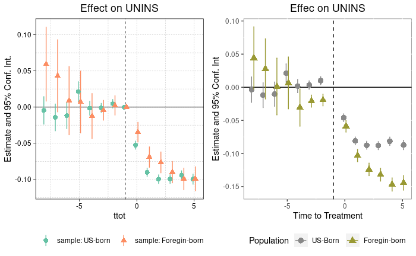

Now I wannt see if I use the same set of covariate for both regression or use different for each what would be the difference

### Checking how adjustment affect estimate on splited result

```r
# with adjustment on two samples
Event= feols( UNINS ~ i(ttot, expansion, ref = -1)+ SEX+DIS+AGEP+SCHLG+POVPIPG+MARG+RACE1+ESRG+ ENG+LTINU+NonCit+ADA+UnempR+IPC |
                   ST + YEAR   ,                        ## FEs
               vcov="hetero",
               #  cluster = "ST",
               weights = ~PWGTP,
               data = Data,
               split= ~NATIVITY)
```

```
Notes from the estimations:
[x 1] The variable 'LTINU' has been removed because of collinearity (see $collin.var).
```

```r
Event1= feols( UNINS ~ i(ttot, expansion, ref = -1)+ SEX+DIS+AGEP+SCHLG+POVPIPG+MARG+RACE1+ESRG+ADA+UnempR  |
                   ST + YEAR   ,                        ## FEs
               vcov="hetero",
               #  cluster = "ST",
               weights = ~PWGTP,
               data = NATV)
```

[output not shown]

### Event study table with adjustment Check different specifications

```r
# with adjustment on two samples including IPC & NonCit
#

Event= feols( UNINS ~ i(ttot, expansion, ref = -1) +
               SEX+DIS+AGEP+SCHLG+POVPIPG+MARG+RACE1+ESRG+ENG+LTINU+NonCit+ADA+UnempR+IPC |
                   ST + YEAR   ,                        ## FEs
               vcov="hetero",
               #  cluster = "ST",
               weights = ~PWGTP,
               data = Data,
               split= ~NATIVITY)
```

```
Notes from the estimations:
[x 1] The variable 'LTINU' has been removed because of collinearity (see $collin.var).
```

```r
Event1= feols( UNINS ~ ForeginBorn*i(ttot, expansion, ref = -1)+
               SEX+DIS+AGEP+SCHLG+POVPIPG+MARG+RACE1+ESRG+ENG+LTINU+NonCit+ADA+UnempR+IPC |
                   ST + YEAR   ,                        ## FEs
               vcov="hetero",
               #  cluster = "ST",
               weights = ~PWGTP,
               data = Data)

Event2= feols( UNINS ~ ForeginBorn*i(ttot, expansion, ref = -1)
               + SEX + DIS+AGEP+POVPIPG+ENG+LTINU+NonCit+ForeginBorn*(SCHLG+ MARG+ RACE1 + ESRG + ADA+UnempR+IPC) |
                ST + YEAR   ,                        ## FEs
              vcov="hetero",
              #  cluster = "ST",
              weights = ~PWGTP,
              data = Data)




etable(Event,Event1,Event2)
```

```
                                                 Event.1              Event.2               Event1               Event2
Sample (NATIVITY)                                US-born         Foregin-born
Dependent Var.:                                    UNINS                UNINS                UNINS                UNINS

expansion x ttot = -8                    0.0050 (0.0096)     0.0559* (0.0236)      0.0048 (0.0095)     -0.0037 (0.0095)
expansion x ttot = -7                   -0.0118 (0.0093)      0.0206 (0.0239)     -0.0143 (0.0092)    -0.0206* (0.0092)
expansion x ttot = -6                   -0.0090 (0.0092)      0.0068 (0.0222)     -0.0127 (0.0091)    -0.0200* (0.0091)
expansion x ttot = -5                 0.0281*** (0.0070)      0.0236 (0.0207)   0.0280*** (0.0069)    0.0221** (0.0069)
expansion x ttot = -4                    0.0020 (0.0050)      0.0044 (0.0155)      0.0035 (0.0049)     -0.0025 (0.0049)
expansion x ttot = -3                   -0.0003 (0.0033)     -0.0093 (0.0073)      0.0014 (0.0031)     -0.0047 (0.0032)
expansion x ttot = -2                    0.0050 (0.0031)    -0.0150* (0.0071)     0.0060* (0.0030)     -0.0001 (0.0030)
expansion x ttot = 0                 -0.0508*** (0.0030)  -0.0226*** (0.0067)  -0.0461*** (0.0029)  -0.0546*** (0.0029)
expansion x ttot = 1                 -0.0858*** (0.0032)  -0.0590*** (0.0071)  -0.0802*** (0.0030)  -0.0894*** (0.0030)
expansion x ttot = 2                 -0.0977*** (0.0032)  -0.0573*** (0.0073)  -0.0897*** (0.0030)  -0.0991*** (0.0030)
expansion x ttot = 3                 -0.0974*** (0.0032)  -0.0734*** (0.0075)  -0.0915*** (0.0030)  -0.0993*** (0.0030)
expansion x ttot = 4                 -0.0920*** (0.0033)  -0.0825*** (0.0076)  -0.0864*** (0.0031)  -0.0946*** (0.0031)
expansion x ttot = 5                 -0.0995*** (0.0038)  -0.0649*** (0.0084)  -0.0915*** (0.0035)  -0.1017*** (0.0036)
SEX                                  -0.0693*** (0.0009)  -0.0594*** (0.0019)  -0.0659*** (0.0008)  -0.0672*** (0.0008)
DIS                                  -0.1427*** (0.0010)  -0.1538*** (0.0030)  -0.1461*** (0.0010)  -0.1441*** (0.0010)
AGEP                                -0.0009*** (4.05e-5) -0.0036*** (9.35e-5) -0.0015*** (3.72e-5) -0.0015*** (3.73e-5)
SCHLG.L                              -0.1157*** (0.0017)  -0.0745*** (0.0036)  -0.1063*** (0.0016)  -0.1150*** (0.0017)
SCHLG.Q                              -0.0130*** (0.0015)  -0.0109*** (0.0031)  -0.0127*** (0.0013)  -0.0122*** (0.0015)
SCHLG.C                               0.0131*** (0.0013)  -0.0135*** (0.0028)   0.0082*** (0.0012)   0.0133*** (0.0013)
SCHLG^4                                  0.0013 (0.0010)  -0.0157*** (0.0025)   -0.0026** (0.0009)      0.0014 (0.0010)
POVPIPG.L                            -0.0238*** (0.0007)  -0.0207*** (0.0013)  -0.0230*** (0.0006)  -0.0230*** (0.0006)
MARG                                 -0.0674*** (0.0010)  -0.0454*** (0.0019)  -0.0619*** (0.0009)  -0.0672*** (0.0010)
RACE1.L                               0.0249*** (0.0017)   0.0413*** (0.0047)   0.0373*** (0.0016)   0.0303*** (0.0017)
RACE1.Q                               0.0418*** (0.0032)     -0.0063 (0.0042)   0.0578*** (0.0019)   0.0378*** (0.0032)
RACE1.C                              -0.0155*** (0.0015)  -0.0863*** (0.0036)  -0.0430*** (0.0013)  -0.0219*** (0.0014)
RACE1^4                               0.0238*** (0.0039)  -0.0614*** (0.0029)  -0.0348*** (0.0018)   0.0250*** (0.0039)
ESRG.L                               -0.0401*** (0.0008)      0.0001 (0.0015)  -0.0291*** (0.0007)  -0.0370*** (0.0008)
ESRG.Q                               -0.1175*** (0.0013)  -0.0621*** (0.0027)  -0.1074*** (0.0012)  -0.1160*** (0.0013)
ENG.L                                 0.0818*** (0.0071)   0.0821*** (0.0029)   0.0867*** (0.0023)   0.0824*** (0.0024)
ENG.Q                                    0.0019 (0.0063)   0.0227*** (0.0023)   0.0126*** (0.0017)     0.0042* (0.0018)
ENG.C                                    0.0049 (0.0051)  -0.0194*** (0.0020)  -0.0110*** (0.0015)  -0.0061*** (0.0015)
ENG^4                                    0.0025 (0.0042)    0.0058** (0.0019)      0.0013 (0.0016)     -0.0006 (0.0016)
ADA                                   0.0314*** (0.0089)  -0.1366*** (0.0232)      0.0038 (0.0083)      0.0056 (0.0084)
UnempR                                0.0028*** (0.0007)   0.0076*** (0.0015)   0.0038*** (0.0006)   0.0035*** (0.0006)
IPC                                     0.0013. (0.0007)   -0.0042** (0.0015)     -0.0003 (0.0006)   0.0027*** (0.0006)
LTINU                                                        -0.0009 (0.0025)      0.0026 (0.0025)     -0.0026 (0.0025)
```

[output cut: 24 more lines]

```
ForeginBorn x ESRG.L                                                                                 0.0336*** (0.0015)
ForeginBorn x ESRG.Q                                                                                 0.0531*** (0.0029)
ForeginBorn x ADA                                                                                      -0.0117 (0.0086)
ForeginBorn x UnempR                                                                                  0.0021** (0.0007)
ForeginBorn x IPC                                                                                   -0.0114*** (0.0006)
Fixed-Effects:                      -------------------- -------------------- -------------------- --------------------
ST                                                   Yes                  Yes                  Yes                  Yes
YEAR                                                 Yes                  Yes                  Yes                  Yes
___________________________________ ____________________ ____________________ ____________________ ____________________
S.E. type                           Heteroskedasti.-rob. Heteroskedasti.-rob. Heteroskedasti.-rob. Heteroskedasti.-rob.
Observations                                   1,585,639              389,955            1,975,594            1,975,594
R2                                               0.12027              0.21428              0.17614              0.17829
Within R2                                        0.06749              0.14204              0.12215              0.12444
---
Signif. codes: 0 '***' 0.001 '**' 0.01 '*' 0.05 '.' 0.1 ' ' 1
```

### plot all adj Event study splited and non splited

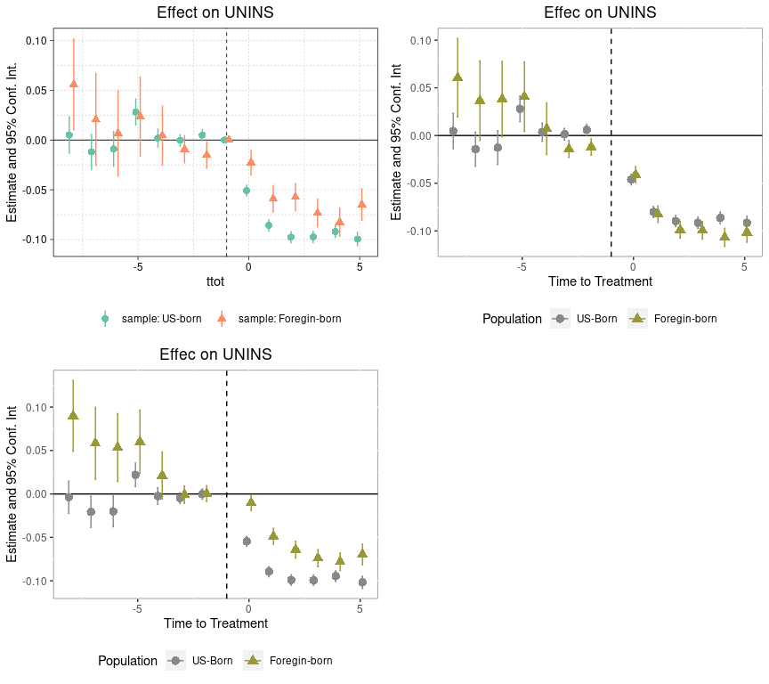

## Static TWFE

Now I started feeling that maybe if I take a look at the samples in the TWFE model two samples then I can chose between model two and three as well.

let’s see:

### TWFE with not adjustment

```r
reg1 = feols(UNINS ~ treat  | ST + YEAR  , vcov = "hetero", weights = ~PWGTP, data = Data,split= ~NATIVITY) # Control for demographic + immigrants + state

reg2 = feols(UNINS ~ treat*ForeginBorn  | ST + YEAR  , vcov = "hetero", weights = ~PWGTP, data = Data) # Control for demographic + immigrants + state

etable(list(reg1,reg2))
```

```
                                     .1                  .2             model 3
Sample (NATIVITY)               US-born        Foregin-born
Dependent Var.:                   UNINS               UNINS               UNINS

treat               -0.0853*** (0.0019) -0.0707*** (0.0039) -0.0749*** (0.0017)
ForeginBorn                                                  0.2442*** (0.0014)
treat x ForeginBorn                                         -0.0310*** (0.0022)
Fixed-Effects:      ------------------- ------------------- -------------------
ST                                  Yes                 Yes                 Yes
YEAR                                Yes                 Yes                 Yes
___________________ ___________________ ___________________ ___________________
S.E. type           Heteroskedast.-rob. Heteroskedast.-rob. Heteroskedast.-rob.
Observations                  1,585,639             389,955           1,975,594
R2                              0.05896             0.08538             0.10174
Within R2                       0.00249             0.00129             0.04288
---
Signif. codes: 0 '***' 0.001 '**' 0.01 '*' 0.05 '.' 0.1 ' ' 1
```

```r
reg1 = feols(UNINS ~ treat + SEX+DIS+AGEP+SCHLG+POVPIPG+MARG+RACE1+ESRG+ENG+LTINU+NonCit+ADA+UnempR+IPC | ST + YEAR  , vcov = "hetero", weights = ~PWGTP, data = Data,split= ~NATIVITY) # Control for demographic + immigrants + state
```

```
Notes from the estimations:
[x 1] The variable 'LTINU' has been removed because of collinearity (see $collin.var).
```

```r
reg2=  feols(UNINS ~ treat*ForeginBorn + SEX + DIS+AGEP+POVPIPG+ENG+LTINU+NonCit+ForeginBorn*(SCHLG+ MARG+ RACE1 + ESRG + ADA+UnempR+IPC)  | ST + YEAR , vcov = "hetero", weights = ~PWGTP, data = Data)

reg3=  feols(UNINS ~ treat*ForeginBorn +SEX+DIS+AGEP+SCHLG+POVPIPG+MARG+RACE1+ESRG+ENG+LTINU+NonCit+ADA+UnempR+IPC  | ST + YEAR , vcov = "hetero", weights = ~PWGTP, data = Data)


etable(list(reg1,reg2,reg3),fitstat=c('n', 'cor2', 'ar2', 'war2',"aic"))
```

```
                                        .1                   .2              model 3              model 4
Sample (NATIVITY)                  US-born         Foregin-born
Dependent Var.:                      UNINS                UNINS                UNINS                UNINS

treat                  -0.0832*** (0.0019)  -0.0485*** (0.0043)  -0.0830*** (0.0018)  -0.0765*** (0.0017)
SEX                    -0.0693*** (0.0009)  -0.0594*** (0.0019)  -0.0672*** (0.0008)  -0.0660*** (0.0008)
DIS                    -0.1427*** (0.0010)  -0.1538*** (0.0030)  -0.1441*** (0.0010)  -0.1462*** (0.0010)
AGEP                  -0.0009*** (4.05e-5) -0.0036*** (9.36e-5) -0.0015*** (3.73e-5) -0.0015*** (3.72e-5)
SCHLG.L                -0.1157*** (0.0017)  -0.0744*** (0.0036)  -0.1150*** (0.0017)  -0.1062*** (0.0016)
SCHLG.Q                -0.0130*** (0.0015)  -0.0110*** (0.0031)  -0.0123*** (0.0015)  -0.0127*** (0.0013)
SCHLG.C                 0.0131*** (0.0013)  -0.0136*** (0.0028)   0.0132*** (0.0013)   0.0082*** (0.0012)
SCHLG^4                    0.0013 (0.0010)  -0.0157*** (0.0025)      0.0014 (0.0010)   -0.0026** (0.0009)
POVPIPG.L              -0.0238*** (0.0007)  -0.0207*** (0.0013)  -0.0230*** (0.0006)  -0.0230*** (0.0006)
MARG                   -0.0674*** (0.0010)  -0.0454*** (0.0019)  -0.0673*** (0.0010)  -0.0620*** (0.0009)
RACE1.L                 0.0248*** (0.0017)   0.0413*** (0.0047)   0.0304*** (0.0017)   0.0376*** (0.0016)
RACE1.Q                 0.0418*** (0.0032)     -0.0064 (0.0042)   0.0376*** (0.0032)   0.0579*** (0.0019)
RACE1.C                -0.0155*** (0.0015)  -0.0864*** (0.0036)  -0.0222*** (0.0014)  -0.0432*** (0.0013)
RACE1^4                 0.0236*** (0.0039)  -0.0613*** (0.0029)   0.0249*** (0.0039)  -0.0350*** (0.0018)
ESRG.L                 -0.0400*** (0.0008)      0.0002 (0.0015)  -0.0370*** (0.0008)  -0.0290*** (0.0007)
ESRG.Q                 -0.1175*** (0.0013)  -0.0621*** (0.0027)  -0.1160*** (0.0013)  -0.1074*** (0.0012)
ENG.L                   0.0816*** (0.0071)   0.0822*** (0.0029)   0.0823*** (0.0024)   0.0865*** (0.0023)
ENG.Q                      0.0018 (0.0063)   0.0228*** (0.0023)     0.0041* (0.0018)   0.0128*** (0.0017)
ENG.C                      0.0049 (0.0051)  -0.0193*** (0.0020)  -0.0060*** (0.0015)  -0.0109*** (0.0015)
ENG^4                      0.0025 (0.0042)    0.0058** (0.0019)     -0.0006 (0.0016)      0.0013 (0.0016)
ADA                      0.0238** (0.0088)  -0.1413*** (0.0221)     -0.0025 (0.0082)     -0.0041 (0.0082)
UnempR                  0.0029*** (0.0007)   0.0092*** (0.0015)   0.0038*** (0.0006)   0.0041*** (0.0006)
IPC                        0.0011 (0.0007)     -0.0018 (0.0014)   0.0030*** (0.0006)      0.0005 (0.0006)
LTINU                                          -0.0009 (0.0025)     -0.0029 (0.0025)      0.0024 (0.0025)
NonCit                                       0.1915*** (0.0023)   0.2054*** (0.0022)   0.2187*** (0.0021)
ForeginBorn                                                      -0.0825*** (0.0185)     0.0364* (0.0176)
treat x ForeginBorn                                               0.0331*** (0.0030)     -0.0033 (0.0021)
ForeginBorn x SCHLG.L                                             0.0407*** (0.0040)
ForeginBorn x SCHLG.Q                                               -0.0015 (0.0034)
ForeginBorn x SCHLG.C                                            -0.0250*** (0.0031)
ForeginBorn x SCHLG^4                                            -0.0185*** (0.0027)
ForeginBorn x MARG                                                0.0191*** (0.0021)
ForeginBorn x RACE1.L                                               0.0083. (0.0049)
ForeginBorn x RACE1.Q                                            -0.0381*** (0.0052)
ForeginBorn x RACE1.C                                            -0.0554*** (0.0038)
ForeginBorn x RACE1^4                                            -0.0908*** (0.0048)
ForeginBorn x ESRG.L                                              0.0334*** (0.0015)
ForeginBorn x ESRG.Q                                              0.0530*** (0.0029)
ForeginBorn x ADA                                                  -0.0184* (0.0078)
ForeginBorn x UnempR                                              0.0031*** (0.0005)
ForeginBorn x IPC                                                -0.0109*** (0.0006)
Fixed-Effects:        -------------------- -------------------- -------------------- --------------------
ST                                     Yes                  Yes                  Yes                  Yes
YEAR                                   Yes                  Yes                  Yes                  Yes
_____________________ ____________________ ____________________ ____________________ ____________________
S.E. type             Heteroskedasti.-rob. Heteroskedasti.-rob. Heteroskedasti.-rob. Heteroskedasti.-rob.
Observations                     1,585,639              389,955            1,975,594            1,975,594
Squared Cor.                       0.11349              0.20568              0.16076              0.15873
Adj. R2                            0.11988              0.21384              0.17787              0.17574
Within Adj. R2                     0.06711              0.14167              0.12402              0.12174
AIC                            1,723,368.1            475,536.5          2,205,813.2          2,210,533.8
---
Signif. codes: 0 '***' 0.001 '**' 0.01 '*' 0.05 '.' 0.1 ' ' 1
```

### TWFE with adjustment

```r
reg1 = feols(UNINS ~ treat + SEX+DIS+AGEP+SCHLG+POVPIPG+MARG+RACE1+ESRG+ENG+LTINU+NonCit+ADA+UnempR+IPC | ST + YEAR  , vcov = "hetero", weights = ~PWGTP, data = Data,split= ~NATIVITY) # Control for demographic + immigrants + state

reg2=  feols(UNINS ~ treat*ForeginBorn + SEX + DIS+AGEP+POVPIPG+ENG+LTINU+NonCit+ForeginBorn*(SCHLG+ MARG+ RACE1 + ESRG + ADA+UnempR+IPC)  | ST + YEAR , vcov = "hetero", weights = ~PWGTP, data = Data)

reg3=  feols(UNINS ~ treat*ForeginBorn +SEX+DIS+AGEP+SCHLG+POVPIPG+MARG+RACE1+ESRG+ENG+LTINU+NonCit+ADA+UnempR+IPC  | ST + YEAR , vcov = "hetero", weights = ~PWGTP, data = Data)


etable(list(reg1,reg2,reg3),fitstat=c('n', 'cor2', 'ar2', 'war2',"aic"))
```

[output not shown]

checking different specification strategy again

```r
Event= feols( UNINS ~ ForeginBorn*i(ttot, expansion, ref = -1) + SEX +DIS+AGEP+POVPIPG+ADA+LTINU+ ForeginBorn*(SCHLG+ MARG+ RACE1 + ESRG+ UnempR+IPC)|
                ST + YEAR  ,                        ## FEs
              vcov="hetero",
              #  cluster = "ST",
              weights = ~PWGTP,
              data = Data)
```